# Infografías automáticas con R

2020-04-25

Necesitaba hacer *inforgrafías automáticas y reproducibles* en R para presentar diferentes indicadores y poder replicar el mismo formato para una gran cantidad de datos con la misma estructura inicial.

Mi inspiración principal estuvo en [este post](https://www.r-bloggers.com/r-how-to-layout-and-design-an-infographic/) que presentaba algunas posibilidades de cómo construir una inforgrafía combinando diferentes paquetes de análisis y visualización. No encontré nada útil en español, así que por eso decidí escribir esto. A continuación dejo el paso a paso:

En primer lugar, debemos decidir qué tipo de grafico o información queremos presentar en la infografía. En este caso necesitaba:

- Gráfico de líneas (serie temporal)
- Gráfico de barras (serie temporal)
- Mapa de densidad
- Pirámide poblacional
- Íconos con datos brutos

También un titulo inicial y un logo!

## Construcción del contenido:

### Paquetes

Los paquetes genéricos que que voy a utilizar son:

```r
library(ggplot2) #visualización
library(dplyr) #manipulación de datos
library(grid) #estructura de cuadrantes de infografía
library(gridExtra) #estructura de cuadrantes de infografía
library(RColorBrewer) #paleta de colores
library(extrafont) #tipos de letras
library(sf) #cargar shape de mapas
library(png) #abrir iconos en formato png
library(classInt) #calcular intervalos
library(useful) #ubica objetos de ggplot en cuadrícula
```

Cómo les comenté, será una inforgrafía *automática* que se aplicará a conjuntos de datos iguales pero con diferente unidad de análisis, por lo que me interesa que cambiando un parámetro inicial, pueda correrlo sin tener que modificar nada del código, por lo que dejo referenciadas de modo variable las rutas, los títulos, etc. creando un objeto *nombre*.

```r
nombre ="Infografia"
```

### Gráfico de línea (serie temporal)

Cargo un archivo con la serie de datos que será insumo para el gráfico de línea y le pongo **serie_linea**. Construyo el gráfico con *ggplot*.

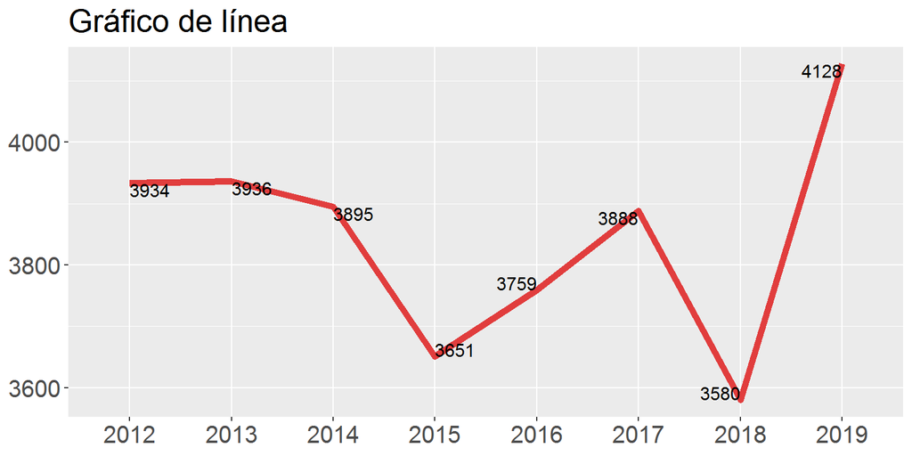

```r
serie_linea_graf = ggplot(serie_linea,aes(x = as.factor(fecha_dato) , y = conteo,group = 1)) +
  geom_line(size=2, stat="identity",colour = "#E13D3D") +
  theme(axis.text.x = element_text(size=15,family = "Impact"), axis.text.y = element_text(size=15,family = "Impact"),plot.title = element_text(size=20,family = "Impact"),axis.title.x=element_blank(),axis.title.y=element_blank())+
  geom_text(aes(label = round(conteo, 1)),
            vjust = "inward", hjust = "inward",
            show.legend = FALSE,size=4,family="Impact")+
  ylab("Casos") + xlab("Año") + ggtitle("Gráfico de línea")
```

### Gráfico de barras (serie temporal)

Cargo un archivo con la serie de datos que será insumo para el gráfico de barras y le pongo **serie_barra**. Construyo el gráfico también con *ggplot*.

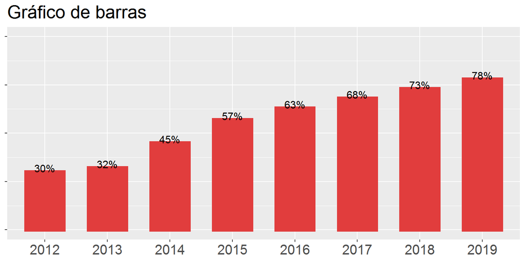

```r
serie_barra_graf = ggplot(serie_barra,aes(x = factor(fecha_dato) , y = conteo,group = 1)) +
  geom_bar(size=2, stat="identity", colour = "#E13D3D",fill = "#E13D3D",width = 0.6) +
   scale_y_continuous(limits = c(0, 100))+
  theme(axis.text.x = element_text(size=15,family = "Impact"), axis.text.y = element_blank(),plot.title = element_text(size=20,family = "Impact"),axis.title.x=element_blank(),axis.title.y=element_blank())+
  geom_text(aes(label = paste0(round(conteo, 1),"%")),
            position = position_dodge(0.9) ,
            vjust = 0,show.legend = FALSE,size=4,family="Impact")+
  ylab("%") + xlab("Año") + ggtitle("Gráfico de barras")
```

### Mapa de densidad

Cargo un archivo con los datos por departamento ( **depto** ) y luego dos archivos de tipo *shape* para tener los polígonos y las coordenadas para construir el mapa de Uruguay, pegándoselos a mis datos originales según una variable común (en este caso el nombre del departamento!). Luego calculo 5 intervalos (con la función *classIntervals*) que serán diferentes según la distribución de los datos que levante (a estos le asigno el nombre *brks*). Construyo el mapa.

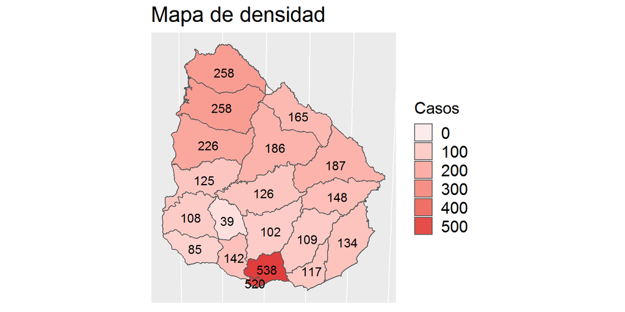

```r
mapa=ggplot() +
  geom_sf(aes(fill = conteo), data = uru) +
  scale_y_continuous(breaks = brks)+
  scale_fill_continuous(high = "#e13d3d", low = "#fcebeb")+
  geom_text(data = subset(coord, coord$conteo !=0), aes(XCOORD, YCOORD -3000 , label = conteo),size = 4,family="Impact") +
  theme(
    axis.line = element_blank(),
    axis.text.x = element_blank(),
    axis.text.y = element_blank(),
    axis.ticks = element_blank(),
    axis.title.x = element_blank(),
    axis.title.y = element_blank(),
    legend.text = element_text(size = 15,family="Impact"),
    legend.title = element_text(size = 15,family="Impact"),
    plot.title = element_text(size=20,family="Impact"),
    panel.border = element_rect(colour = "#ffffff", fill = NA, size = 0.5))+
    guides(fill=guide_legend(title="Casos"))+
    ggtitle("Mapa de densidad")
```

### Piramide poblacional

Cargo los datos de la piramide, objeto *piramide* y calculo el inverso cuando es Varón. Armo el gráfico.

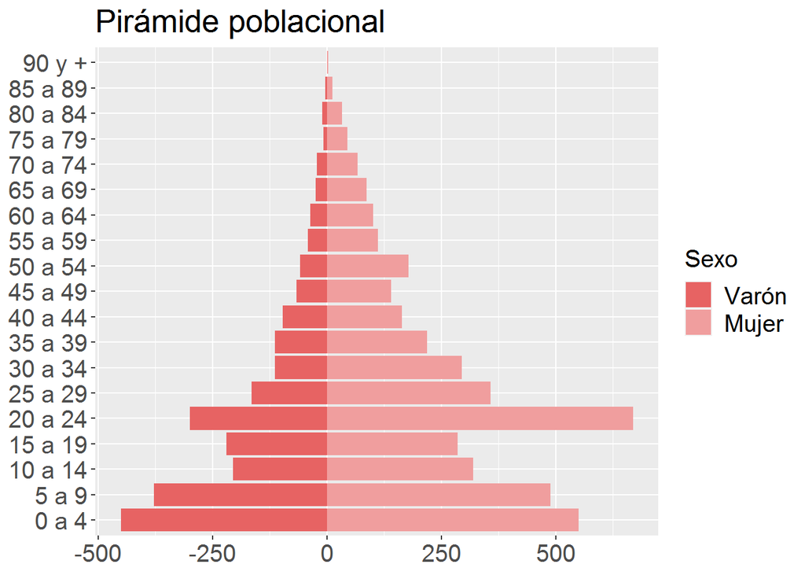

```r
piramide$Var1 <- as.character(piramide$Var1)
piramide$Var1 <- factor(piramide$Var1, levels=c("0 a 4","5 a 9","10 a 14","15 a 19","20 a 24","25 a 29","30 a 34","35 a 39","40 a 44","45 a 49","50 a 54","55 a 59","60 a 64","65 a 69","70 a 74","75 a 79","80 a 84","85 a 89","90 y +"))

piramide$Freq <- ifelse(piramide$Var2 == "Varón", -1*piramide$Freq, piramide$Freq)


piramide_graf=ggplot(piramide, aes(x = Var1, y = Freq, fill = Var2)) +
  geom_bar(data = subset(piramide, Var2 == "Mujer"), stat = "identity") +
  geom_bar(data = subset(piramide, Var2 == "Varón"), stat = "identity") +
  scale_fill_manual(values = c("#f09e9e","#e76363"))+
  coord_flip()+
  theme(axis.text.x = element_text(size=15,family = "Impact"), axis.text.y = element_text(size=15,family = "Impact"),axis.title.x = element_blank(),axis.title.y = element_blank(),legend.text = element_text(
    size = 15,family = "Impact"),legend.title = element_text(
      size = 15,family = "Impact"),plot.title = element_text(size=20,family = "Impact"))+
  guides(fill=guide_legend(title="Sexo",reverse = T))+
  ggtitle("Pirámide poblacional")
```

### Íconos con datos y logo

Cargo los íconos que quiero incluir con la función *readPNG()* y asignandolo a objetos correlativos (icon1,icon2...). También un objeto *datos* con los datos brutos que me interesa incluir.

## Armado de la infografía:

Ahora ya tenemos todos los elementos que incluiremos en la inforgrafía, por lo que debemos construirla incluyendo a todos:

En primer lugar, con la función *pdf()* le digo qué quiero que me guarde la infografía en pdf (podría haber sido jpg, png, etc.), dónde quiero que se guarde y el tamaño de la misma. En este caso quería que sea horizontal pero podría ser vertical.

En segundo lugar, defino los parámetros para diseñar la cuadrícula que tendré como referencia para ubicar los elementos. En este caso es una cuadrícula de 12 x 12. Todo esto lo hago con el paquete *grid*.

```r
pdf(paste0("/",nombre,".pdf"), width = 40, height = 22)

grid.newpage()
pushViewport(viewport(layout = grid.layout(12,12)))
```

Ahora, usamos las funciones *grid.rect* para poner una línea recta, *grid.text* para incluir texto, *grid.raster* para insertar imágenes y la función *print* para insertar los objetos gráficos construidos anteriormente. Con la función *vplayout* defino el lugar de la cuadrícula en que quiero ubicar el elemento en cuestión. También en cada función se setean los tipos y formatos de letra, tamaños, alineación, etc.  
*(dejo comentado lo que costruye en cada línea)*

```r
#Línea recta del encabezado
grid.rect(gp = gpar(fill = "#E13D3D", col = "#E13D3D"), x = unit(0.5, "npc"), y = unit(0.82, "npc"), width = unit(1, "npc"), height = unit(1.2, "npc"),vp = vplayout(1,1:11))
#Título
grid.text("INFOGRAFÍA EN R",gp = gpar(fontsize = 45, fontface ="bold",fontfamily = "Impact", col = "#000000"),just = c("left"),vp = vplayout(1,1))
#Logo de R a la derecha
grid.raster(logo,width = unit(0.6, "npc"),height=unit(0.6, "npc"),vp = vplayout(1,12))

#Inserto gráficos
print(serie_linea_graf, vp = vplayout(2:6, 1:6))
print(mapa, vp = vplayout(8:12, 1:3))
print(piramide_graf, vp = vplayout(8:12,4:6))
print(serie_barra_graf, vp = vplayout(8:12,7:12))

#ÍconoS con datos
#Título
grid.text("Iconos con datos",gp = gpar(fontsize = 30, fontfamily = "Impact"),just = c("left"),vp = vplayout(2,8))

#Ícono y dato 1
grid.raster(icon1,width = unit(0.3, "npc"),height=unit(0.5, "npc"),vp = vplayout(3,8))
grid.text("Dato 1",gp = gpar(fontsize = 30, fontfamily = "Impact"),just = c("left"),vp = vplayout(3,9))
grid.text(datos[1,2],gp = gpar(fontsize = 32, fontface = "bold",fontfamily = "Impact"),just = c("right"),vp = vplayout(3,11))

#Ícono y dato 2
grid.raster(icon2,width = unit(0.3, "npc"),height=unit(0.5, "npc"),vp = vplayout(4,8))
grid.text("Dato 2",gp = gpar(fontsize = 30, fontfamily = "Impact"),just = c("left"),vp = vplayout(4,9))
grid.text(datos[2,2],gp = gpar(fontsize = 32, fontface = "bold",fontfamily = "Impact"),just = c("right"),vp = vplayout(4,11))

#Ícono y dato 3
grid.raster(icon3,width = unit(0.3, "npc"),height=unit(0.5, "npc"),vp = vplayout(5,8))
grid.text("Dato 3",gp = gpar(fontsize = 30, fontfamily = "Impact"),just = c("left"),vp = vplayout(5,9))
grid.text(datos[3,2],gp = gpar(fontsize = 32, fontface = "bold",fontfamily = "Impact"),just = c("right"),vp = vplayout(5,11))

#Ícono y dato 4
grid.raster(icon4,width = unit(0.3, "npc"),height=unit(0.5, "npc"),vp = vplayout(6,8))
grid.text("Dato 4",gp = gpar(fontsize = 30, fontfamily = "Impact"),just = c("left"),vp = vplayout(6,9))
grid.text(datos[4,2],gp = gpar(fontsize = 32, fontface = "bold",fontfamily = "Impact"),just = c("right"),vp = vplayout(6,11))
```

## Versión final:

[figure not shown]